# Player Distributions with Game Types and Finishes

## Overview

In this analysis we will explore who plays chess games, which types of games they play, and how those games end. First, we will begin by exploring the intersection of those 3 ideas. Then, we will explore each one independently more in depth.

For consistency with future analyses this analysis only covers games with complete data in April 2017 which have computer evaluations. In total, this covers 1,112,800 games.

## Player Distributions with Game Types and Finishes

We are not seeking to create an engine which judges how well a came is played ([Stockfish](https://stockfishchess.org/) has that covered extremely well), rather, we are trying to understand *which* games are played and *how* they are played by the different ratings of players who play them.

### Player Pairing Differences in Tournament and Non-Tournament Games

All players have an Elo rating which attempts to quantify their chess skill. In any online game, typically it’s preferred if similarly skilled players are matched against each other. This heat map shows that games typically occur between players in similar Elo rating ranges. However, in tournaments, players can be matched against anyone else who has signed up for that tournament creating more unbalanced games.

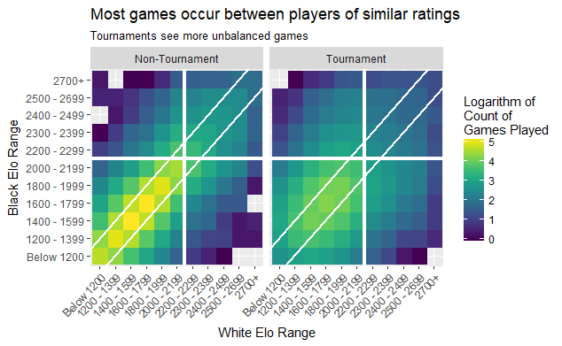

*Note: The verticle and horizontal white lines indicate starting ranges for titled players (e.g. Grandmasters)*

### Game Endings in Different Game Types

Lichess classifies games by their time control settings of how many minutes are initially on the clock for each player and how many seconds are added after each move. UltraBullet games are the quickest with 15 initial seconds for each player for all their moves over the entire game and no increment. Correspondence games are the longest with days allocated for each move. This stacked bar graph shows that games of different lengths of time controls typically end in different ways. In particular, many UltraBullet games simply end by one player’s time running out before a checkmate has been achieved (Time forfeit). However, the way games end for a particular time control variation does not change much for Tournament and Non-Tournament games.

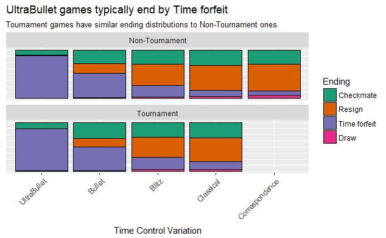

### Classical Draw Likelihood

Classical is the longest game variation classification where the game is expected to be completed in one sitting. These games have an initial clock setting for each player at 7 or more minutes (although, hours for each player is also commonly seen). This setting allows players the most time to think about the board positions and anticipate how the game will play out. This heatmap shows that draws are most likely to occur when two higher rated players play against each other. This may be due to the fact that both players can more easily see that the game will get to the point where neither can win and agree to a draw or either player can force the game into a drawing position.

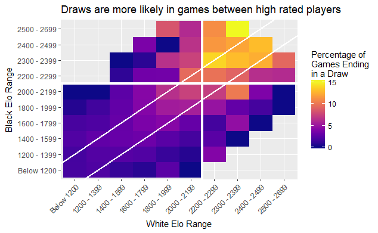

### Blitz Resign vs. Checkmate

Blitz is the next fastest time control variation with an initial clock setting for each player between 3 and 7 minutes. Removing games that end in a draw or end because one player runs out of time, this heatmap shows the difference in games ending by resignation (lighter squares) and checkmate (darker squares). It shows that when two higher rated players play, one of them is more likely to resign than when two lower rated players play. Like the last heatmap, this may be due to the fact that higher rated players can see when they are going to be checkmated and resign ahead of time.

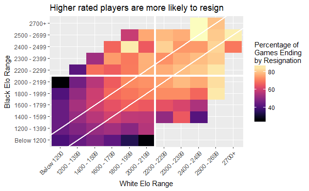

### Bullet Time Forfeit vs. Resign or Checkmate

Bullet is the second fastest time control variation with an initial clock setting for each player greater than 15 seconds and less than 3 minutes. Removing games that end in a draw, this heatmap shows the difference in games ending by time forfeit (lighter squares) and resign or checkmate (darker squares). It shows that when two higher rated players play, they are more likely to complete the game (either by checkmating their opponent or resigning ahead of being checkmated) rather than simply running out of time. Even in these short games, high rated players are consistently able to play an entire game!

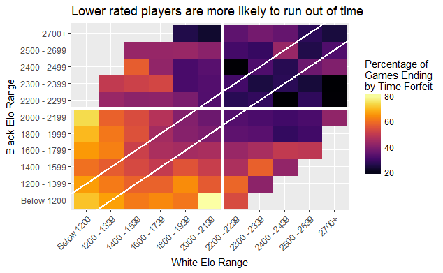

### All Player Pairing Variations

Finally, for completeness, these heatmaps expand further on pairings across time control variations and whether or not it was a tournament game.

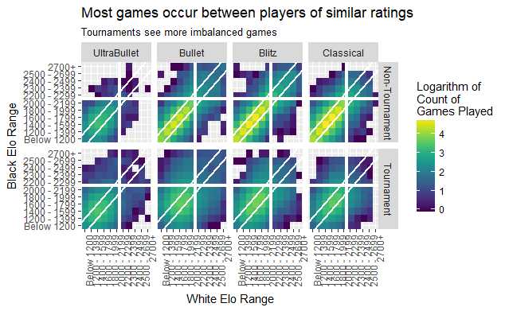

## Player Distributions

In this section, we will look at the Elo ratings regardless of which time control variation is being played or how the game ended.

### Elo Density Plot

This density plot shows that the rating distributions are similar for White and Black players as indicated by the abundance of purple showing where the White and Black rating plots overlap. This shows that Lichess does a good job of not setting higher rated players to one particular color.

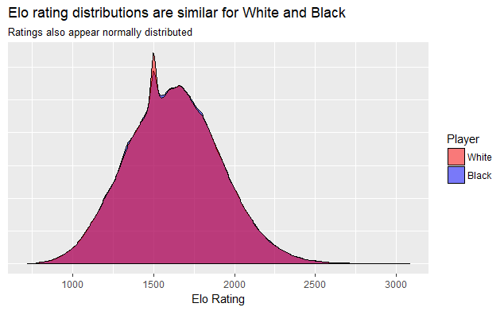

### Elo Range Heatmap

This heatmap shows the pairings of all player ratings. While players of all ratings can and have met in games, in general, Lichess matches similarly rated players.

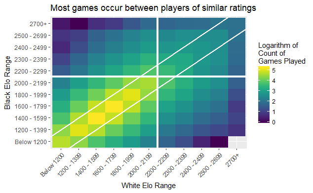

### Titled Players’ Max Elo

As players progress in their career, they can earn titles by their home countries as well as the world governing body for chess – FIDE. Titles are earned by attaining a minimum rating and performing well in certain tournaments. Once earning a title, players can have this title show up with their username on Lichess. If a player does not have a national or FIDE title, Lichess may provide a title upon reaching certain criteria. The progression through the titles is:

1. National Master
2. Candidate Master
3. FIDE Master
4. International Master
5. Grandmaster

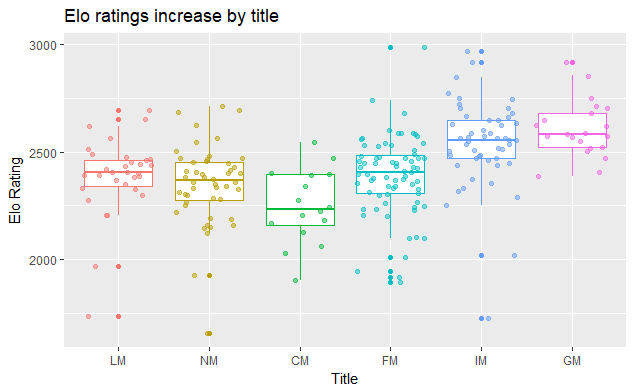

### Titled Players’ Max Elo as a Density Plot

We can also plot the titled players’ max Elo ratings in a density plot. This allows us to compare the peaks of the distributions rather than the medians from the boxplots.

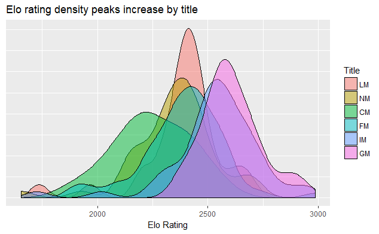

## Game Types

In this section, we will look at the time control variations played regardless of player Elo ratings or how the game ended.

### Games Played by Type

Lichess classifies games as either UltraBullet, Bullet, Blitz, Classical, and Correspondence. Lichess also offers the opportunity to organize online tounraments.

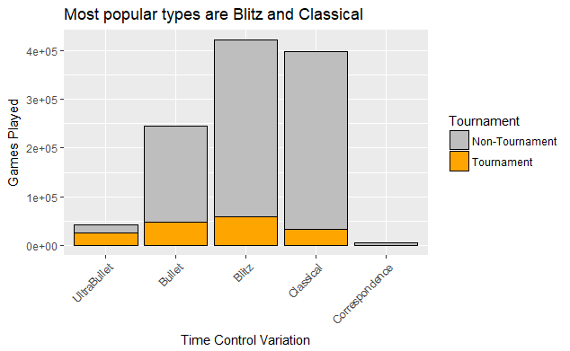

### Games Played by Time Controls

While players are free to set any time controls they wish, typically shorter time controls are more popular as this scatterplot shows having the majority of large points at less than 25 minutes and 25 second increments.

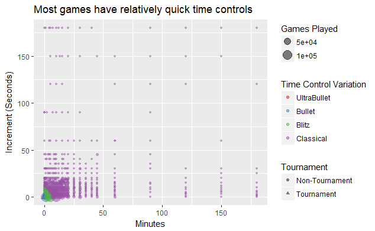

### UltraBullet, Bullet, and Blitz Games Played by Time Controls

UltraBullet, Bullet, and Blitz have the shortest time controls. Anything longer than Blitz is classified as Classical. Correspondence is a special case where players are given multiple days per move. This scatterplot shows that multiple settings are played, only a few are popular. Tournaments tend to be set at these few popular time control settings.

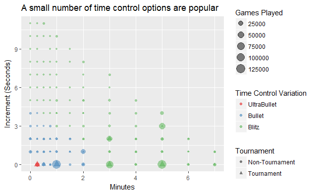

### Classical Games with Less than 25 Minutes and Less Than 25 Second Increment Played by Time Controls

While Classical games have any time control settings longer than Blitz’s, the most popular settings are still relatively quick at less than 25 minutes and less than 25 second increments. Even when viewing this subset, this scatterplot shows that one time control is the most popular – 10 minutes and 0 second increments (typically written 10+0).

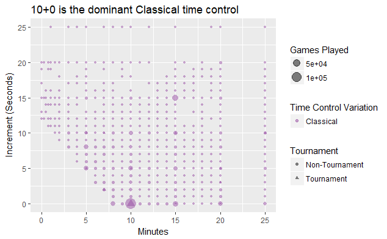

## Game Endings

In this section, we will look at how games end regardless of the time control variations played or player Elo ratings.

### PGN Coded

[Portable Game Notation](https://en.wikipedia.org/wiki/Portable_Game_Notation) specifies how to encode information about chess games. In particular, it specifes how to record Termination and Result. This stacked bar graph shows these combinations for the data.

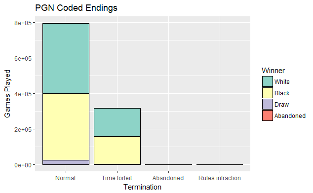

### Normal Endings Recoded

When games have “Normal” endings where either White or Black wins, it may be interesting to view the data by whether there was a checkmate or one of the players resigned. For this analysis, we have recoded the endings as shown by this bar graph.

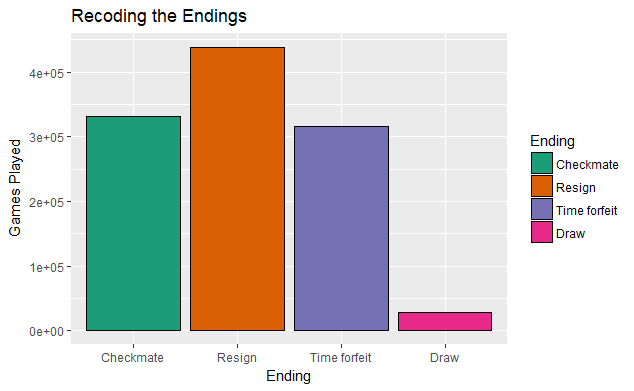

## Thanks

Thank you again to **Lichess** for making this data available for free! And thank you to **you** for reading this analysis!